# R final Project-Condori

2023-10-06

## R final Project - Imports Analysis

Author: Samuel Condori

For this project, I will analyze Imports data from Latin America to the USA on December 2022 reported by the FDA(https://datadashboard.fda.gov/ora/cd/impentry-table.htm)

Step 1: Load all the datasets that I stored in the folder: R_project by creating a list and then use lapply to read them. Then, I united them by using do.call (rbind, ) since the IDs were not repeated and the columns where the same

```r
file_l<- list.files('C:/Users/samal/OneDrive/Desktop/R_project', pattern = ".csv", all.files = TRUE, full.names = TRUE)

South <- lapply(file_l, read.csv)

SouthAmerica_Imports <- do.call(rbind, South)
```

Step 2: I checked at the data sets and notices that it did not had values to perform statistical analysis, but it contain IDs of each import. So, I decided to use the count of these IDs as volume of imports. In total, there were 47 thousand of import entries from South America to the USA.

```r
library(dplyr)
```

```r
library(ggplot2)
Total_imp <- nrow(SouthAmerica_Imports)
```

Step 3: I grouped the imports by its main categories to see which category was the most popular import. Human Food was the largest by far - 92%.

```r
## Product_Categories
Total_imports <- SouthAmerica_Imports %>%
  group_by(Product.Category) %>%
  summarise(Count_Imports = length(Shipment.ID)) %>%
  mutate(Percent_total = Count_Imports/Total_imp*100) %>%
  arrange(desc(Count_Imports))
Total_imports
```

```
## # A tibble: 7 × 3
##   Product.Category    Count_Imports Percent_total
##   <chr>                       <int>         <dbl>
## 1 Human Food                  43669        92.0
## 2 Cosmetics                    1133         2.39
## 3 Devices                      1101         2.32
## 4 Animal Feed                  1065         2.24
## 5 Drugs and Biologics           292         0.615
## 6 Tobacco Products              111         0.234
## 7 Radiological Health            91         0.192
```

Step 4: I used a visualization to see the distribution of imports categories

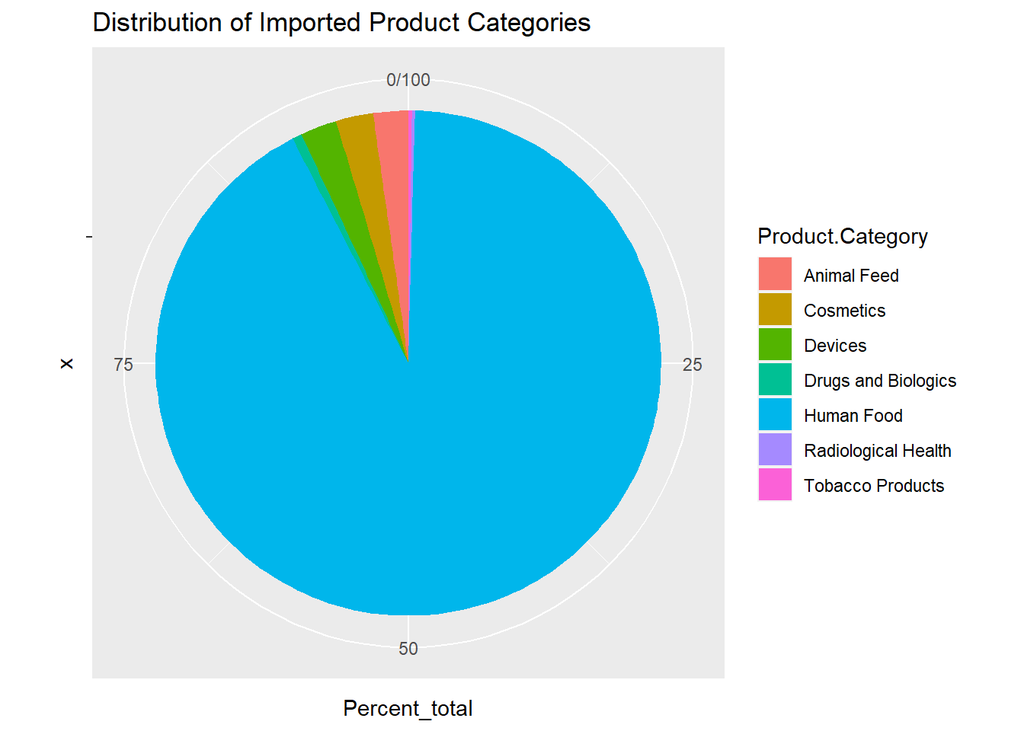

```r
ggplot(Total_imports, aes(x="", y=Percent_total, fill=Product.Category)) +
  geom_bar(stat="identity", width=1) +
  coord_polar(theta="y") +
  labs(title="Distribution of Imported Product Categories")
```

Step 5: I analyzed the human food category and break it down in groups to see which ones where the most popular products. Salmon accounted for almost 12% of total imports!

```r
Human_Food_Analysis <- SouthAmerica_Imports %>%
  filter(Product.Category == "Human Food") %>%
  group_by(Product.Code.Description ) %>%
  summarise(Count_Imports = length(Shipment.ID)) %>%
  mutate(Percent_total = Count_Imports/Total_imp*100) %>%
  arrange(desc(Count_Imports))


 Human_Food_Analysis
```

```
## # A tibble: 849 × 3
##    Product.Code.Description                          Count_Imports Percent_total
##    <chr>                                                     <int>         <dbl>
##  1 SALMON, ALL, AQUACULTURE HARVESTED FISHERY/SEAFO…          5626         11.9
##  2 BANANA (SUBTROPICAL AND TROPICAL FRUIT)                    4573          9.64
##  3 FLAVORING AGENTS AND ADJUVANTS (FOOD ADDITIVES F…          4315          9.09
##  4 GRAPES (BERRY)                                             3677          7.75
##  5 WINE, RED (STILL)                                          2063          4.35
##  6 BLUEBERRIES (BERRY)                                        1649          3.47
##  7 SHRIMP AND PRAWNS, AQUACULTURE HARVESTED FISHERY…          1646          3.47
##  8 MANGO (SUBTROPICAL AND TROPICAL FRUIT)                     1370          2.89
##  9 ASPARAGUS (LEAF & STEM VEGETABLE)                          1126          2.37
## 10 CHERRY FRUIT (PIT FRUIT)                                    993          2.09
## # ℹ 839 more rows
```

Step 6: I checked the most popular product by country

```r
# Max product imported by Country

Most_product_bycountry <- SouthAmerica_Imports %>%
  filter(Product.Category == "Human Food") %>%
  group_by(Country.of.Origin, Product.Code.Description) %>%
  summarise(Count_Imports = length(Shipment.ID)) %>%
  top_n(n = 1, wt = Count_Imports) %>%
  arrange(desc(Count_Imports))
Most_product_bycountry
```

```
## # A tibble: 8 × 3
## # Groups:   Country.of.Origin [8]
##   Country.of.Origin Product.Code.Description                       Count_Imports
##   <chr>             <chr>                                                  <int>
## 1 Chile             SALMON, ALL, AQUACULTURE HARVESTED FISHERY/SE…          5626
## 2 Ecuador           BANANA (SUBTROPICAL AND TROPICAL FRUIT)                 4529
## 3 Peru              GRAPES (BERRY)                                          3521
## 4 Brazil            FLAVORING AGENTS AND ADJUVANTS (FOOD ADDITIVE…          1959
## 5 Argentina         FLAVORING AGENTS AND ADJUVANTS (FOOD ADDITIVE…          1906
## 6 Uruguay           FLAVORING AGENTS AND ADJUVANTS (FOOD ADDITIVE…           448
## 7 Bolivia           QUINOA SEED (EDIBLE SEED)                                 65
## 8 Paraguay          SUNFLOWER OIL, CRUDE                                      44
```

Step 7: I decided to look further into the imports of Salmon, so I needed first to calculate its import volum with nrow.

```r
Human_Food_Filtered <- SouthAmerica_Imports %>%
  filter(Product.Code.Description == "SALMON, ALL, AQUACULTURE HARVESTED FISHERY/SEAFOOD PRODUCTS")
Count_sal_total <- nrow(Human_Food_Filtered)
```

Step 8: Previously, I saw that this product is the most popular from Chile, so I wanted to check the areas where this product is produced. Also, I calculated the influence of each manufacturer region/city by dividing its volume of imports by the total number of Salmon imports. Puerto Montt is the largest, followed by Calbuco, Quellon and Puerto Chacabuco, cities that belong to the sourthern region of Chile.

```r
# Show where the most popular product is coming from

Origin_product <- SouthAmerica_Imports %>%
  filter(Product.Code.Description == "SALMON, ALL, AQUACULTURE HARVESTED FISHERY/SEAFOOD PRODUCTS") %>%
  group_by(Country.of.Origin,Manufacturer.City.Name) %>%
  summarise(Count_Imports = length(Shipment.ID)) %>%
   mutate(Percent_total = Count_Imports/Count_sal_total*100)%>%
  arrange(desc(Count_Imports))
Origin_product
```

```
## # A tibble: 28 × 4
## # Groups:   Country.of.Origin [1]
##    Country.of.Origin Manufacturer.City.Name Count_Imports Percent_total
##    <chr>             <chr>                          <int>         <dbl>
##  1 Chile             Puerto Montt                    2089         37.1
##  2 Chile             Calbuco                          770         13.7
##  3 Chile             Quellon                          687         12.2
##  4 Chile             Puerto Chacabuco                 609         10.8
##  5 Chile             Punta Arenas                     320          5.69
##  6 Chile             Quemchi                          210          3.73
##  7 Chile             Talcahuano                       205          3.64
##  8 Chile             Santiago                         149          2.65
##  9 Chile             Puerto Natales                   102          1.81
## 10 Chile             Porvenir                         100          1.78
## # ℹ 18 more rows
```

Step 9: I checked at the areas where these product arrived, and I saw that almost 70% of Chilean Salmon comes to the Southeast, followed by the West Coast with a lower share, 15%.

```r
# Where is it Landing

Port_to_USA <- SouthAmerica_Imports %>%
  filter(Product.Code.Description == "SALMON, ALL, AQUACULTURE HARVESTED FISHERY/SEAFOOD PRODUCTS") %>%
  group_by(Port.of.Entry.Division) %>%
  summarise(Count_Imports = length(Shipment.ID)) %>%
  mutate(Percent_total = (Count_Imports/Count_sal_total)*100)%>%
  arrange(desc(Count_Imports))


Port_to_USA
```

```
## # A tibble: 5 × 3
##   Port.of.Entry.Division              Count_Imports Percent_total
##   <chr>                                       <int>         <dbl>
## 1 Division of Southeast Imports                3885        69.1
## 2 Division of West Coast Imports                844        15.0
## 3 Division of Northeast Imports                 535         9.51
## 4 Division of Southwest Imports                 337         5.99
## 5 Division of Northern Border Imports            25         0.444
```

Step 10: I analyzed the volume of imports by date of arrival in registered in this month. Then I checked at the trends.

I noticed that some entries took place before and after December 22, so I cleaned it up and only calculate with December dates.

```r
#transform to Date
class(SouthAmerica_Imports$Arrival.Date)
```

```
## [1] "character"
```

```r
SouthAmerica_Imports$Arrival.Date <- as.Date(SouthAmerica_Imports$Arrival.Date, format="%m/%d/%Y")
# how often does it land during this month?

DateImp_Salmon <- SouthAmerica_Imports %>%
  filter(
    Product.Code.Description == "SALMON, ALL, AQUACULTURE HARVESTED FISHERY/SEAFOOD PRODUCTS" &
    Arrival.Date >= as.Date("2022-12-01") &
    Arrival.Date <= as.Date("2022-12-31")
  ) %>%
  group_by(Arrival.Date) %>%
  summarise(Count_Imports = length(Shipment.ID)) %>%
  arrange(Arrival.Date)
```

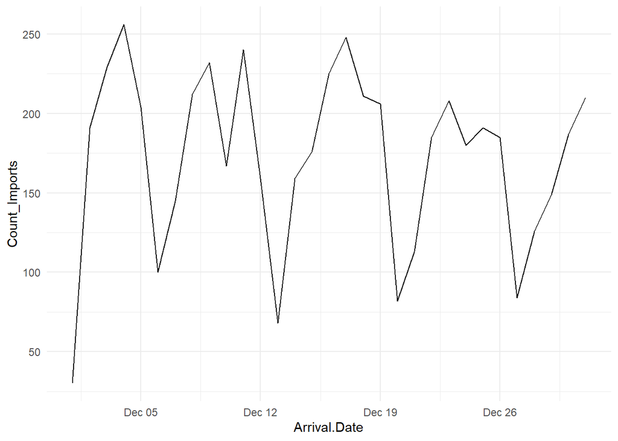

```r
ggplot(DateImp_Salmon, aes(x= Arrival.Date, y= Count_Imports))+
  geom_line()+
  theme_minimal()
```